# Análisis comparativo de las condiciones oceanográficas frente al Perú antes y después de El Niño 1982-1983

Rafael M. Varas Malca

## Introducción

El evento del Niño de 1982-83 fue calificado de intensidad extraordinaria, con un incremento de la Temperatura Superficial del Mar (SST, por sus siglas en inglés) frente a la costa norte del Perú de hasta de 10° celsius (MINAM, 2014). Las condiciones oceanográficas posteriores a dicho evento son de particular interés para saber en qué momento la productividad primaria se reestableció en las costas del Perú respecto a años anteriores al evento. Debido a ello, en este trabajo se comparan dos parámetros: la SST y la productividad primaria entre los años 1978-1981 y 1984-1987.

## Materiales y métodos

Se usó la base de datos de parámetros oceanográficos del Max-Plank-Institut für Meteorologie (proporcionado por Oliveros-Ramos, com. pers., 2017) que contienen datos de la Temperatura Superficial del Mar (SST), Salinidad (SSS), integración vertical de la producción de fitoplankton pequeño (sphy) y grande (lsphy) y pH, desde 1959 hasta el 2005 (representada en 552 meses). Se seleccionaron los meses correspondientes a enero-diciembre de en el lapso de 1978-1981 (228-275), 1982 (276), 1983 (288-299), 1984 (300-311), 1985 (312-323) y 1987 (336-347) para las comparaciones respectivas. Los datos fueron trabajados en el software R (Ver. 3.4.0). Se instalaron los paquetes Fields, Maps, ncdf4, Kali para la obtención de los gráficos.

Las anomalías de la SST se obtuvieron mediante la diferencia entre el valor de la SST promedio de los rangos mencionados y el año estudiado.

En el caso de la productividad primaria, debido a que no se cuenta como proxy la Clorofila A satelital, se ha tomado en cuenta la integración vertical del fitoplankton, aunque no se especifica la profundidad de las muestras.

## Resultados y discusión

### Temperatura Superficial del Mar

La SST para el año de El Niño 1982-83 se muestra a continuación:

[output not shown]

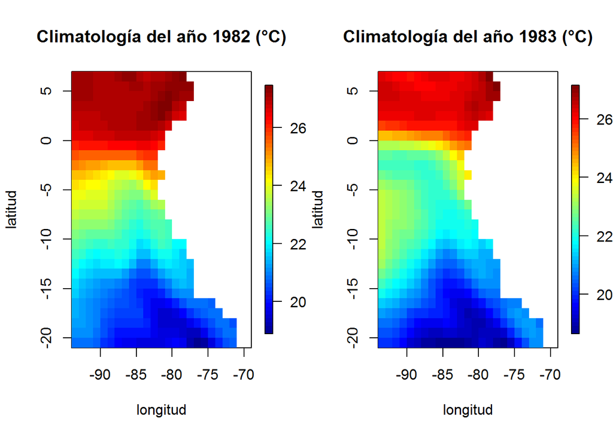

Figura 1. Climatologías para los años de El Niño 1982-1983

Para el caso de la variación de la SST respecto al SST promedio visto entre 1978-1981, se muestra a continuación en la figura 2:

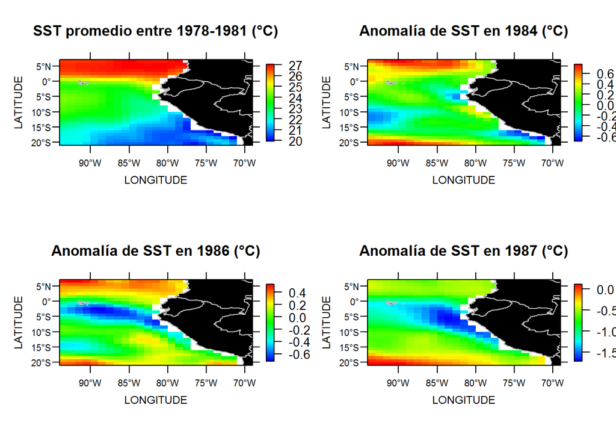

Figura 2. Temperatura superficial del mar en la década de 1980 en el Pacífico suroriental

La SST promedio en el rango 1978-1981 fluctúa entre los 25-20°C a lo largo de la costa peruana. Al comparar con la climatología de la figura 1, se distingue claramente un aumento de la SST hasta los 5°S en 1982, el cual disminuye para 1983. En 1984 se observa un panorama similar a 1983 tomando en cuenta el rango de anomalías de la SST (figura 2), salvo una ligera tendencia a la dismunución de la SST frente a las costas del norte y centro del país. Este patrón se intensifica en 1986 y se extiende hasta el centro del país en 1987.

### Productividad Primaria

La Producción primaria se estima para fitoplankton de gran y menor tamaños a lo largo de una columna de agua. Se presenta a continuación su concentración para 1981 y 84-86.

[figure not shown]

Figura 3. Variación de la Productividad primaria en la década de 1980. Líneas rojas = Fitoplankton pequeño, líneas azules= Fitoplankton grande

El periodo de 1984 muestra un patrón distinto a lo observado en años previos (e.g. 1981) o posteriores (e.g. 1985,86). Recién en 1985 se observa un comportamiento similar al de 1981, tanto en el fitoplakton de diámetro pequeño como grande (ver figura 3).

## Conclusiones

Se puede inferir que las condiciones previas a la ocurrencia del Niño 1982-83 tanto en la SST como en la PP tardaron en reestablecerse de acuerdo a la base de datos analizada.

## Referencias

MINAM (2014) El fenómeno El Niño en el Perú.